Exercise 9 Claire Brandes 2024-03-28

# Exercise 9: Practice Simple Linear Regression

# Step 1

Loading data

```r
library(tidyverse)
f <- "https://raw.githubusercontent.com/difiore/ada-2024-datasets/main/Street_et_al_2017.csv"
d <- read_csv(f, col_names = TRUE)
```

Exploratory data analysis (median, min, max, 1st and 3rd quartiles, mean, sd)

```r
library(skimr)
d <- na.omit(d)
my_skim <- skim_with(numeric = sfl(
                                   p0 = NULL,
                                   p50 = NULL,
                                   p100 = NULL,
                                   hist = NULL,
                                   median,
                                   min,
                                   max,
                                   p25 = ~ quantile(., probs = .25),
                                   p75 = ~quantile(., probs = .75),
                                   mean,
                                   sd))
my_skim(d, where(is.numeric))
```

Data summary

| Name | d |
| --- | --- |
| Number of rows | 76 |
| Number of columns | 13 |
| _______________________ |  |
| Column type frequency: |  |
| numeric | 11 |
| ________________________ |  |
| Group variables | None |

**Variable type: numeric**

| skim_variable | n_missing | complete_rate | mean | sd | p25 | p75 | median | min | max |
| --- | --- | --- | --- | --- | --- | --- | --- | --- | --- |
| Social_learning | 0 | 1 | 5.87 | 26.70 | 0.00 | 2.00 | 0.00 | 0.00 | 214.00 |
| Research_effort | 0 | 1 | 74.16 | 116.43 | 17.00 | 79.50 | 36.50 | 1.00 | 755.00 |
| ECV | 0 | 1 | 73.37 | 89.60 | 11.48 | 95.30 | 60.44 | 1.63 | 490.41 |
| Group_size | 0 | 1 | 14.22 | 15.70 | 3.14 | 20.25 | 8.12 | 1.00 | 85.00 |
| Gestation | 0 | 1 | 162.61 | 39.70 | 134.67 | 180.66 | 165.51 | 60.34 | 259.42 |
| Weaning | 0 | 1 | 308.97 | 272.42 | 119.53 | 374.48 | 211.77 | 40.45 | 1260.81 |
| Longevity | 0 | 1 | 337.68 | 138.70 | 230.10 | 416.70 | 313.80 | 103.00 | 720.00 |
| Sex_maturity | 0 | 1 | 1429.31 | 983.05 | 663.06 | 1894.11 | 1298.11 | 298.91 | 5465.72 |
| Body_mass | 0 | 1 | 8352.93 | 16736.83 | 695.00 | 8357.25 | 3580.00 | 65.00 | 120950.00 |
| Maternal_investment | 0 | 1 | 471.57 | 303.86 | 252.35 | 557.59 | 382.73 | 100.79 | 1492.30 |
| Repro_lifespan | 0 | 1 | 8841.66 | 3560.22 | 6129.50 | 10701.18 | 8243.77 | 2512.16 | 18581.38 |

## Step 2

Plot brain size as a function of social group size, longevity, juvenile period length, and reproductive lifespan

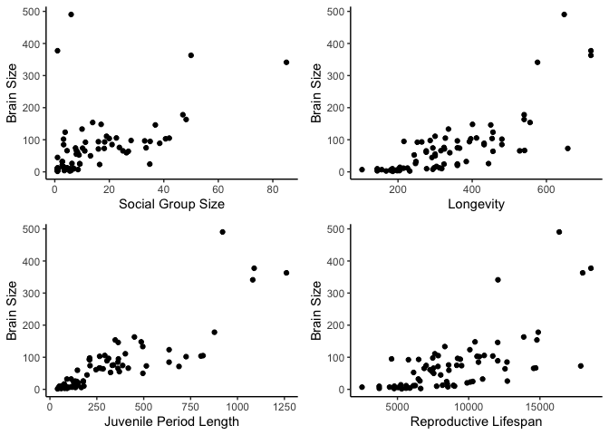

```r
sgs_ECV <- ggplot(d, aes(x = Group_size, y = ECV)) +
  geom_point() +
  theme_classic() +
  xlab("Social Group Size") + ylab("Brain Size")

Lon_ECV <- ggplot(d, aes(x = Longevity, y = ECV)) +
  geom_point() +
  theme_classic() +
  xlab("Longevity") + ylab("Brain Size")

jpl_ECV <- ggplot(d, aes(x = Weaning, y = ECV)) +
  geom_point() +
  theme_classic() +
  xlab("Juvenile Period Length") + ylab("Brain Size")

repro_ECV <- ggplot(d, aes(x = Repro_lifespan, y = ECV)) +
  geom_point() +
  theme_classic() +
  xlab("Reproductive Lifespan") + ylab("Brain Size")

library(ggpubr)
ggarrange(sgs_ECV, Lon_ECV, jpl_ECV, repro_ECV)
```

## Step 3

Derive by hand the ordinary least squares regression coefficients $\beta1$ and $\beta0$ for ECV as a function of social group size

```r
s3 <- d %>% filter(!is.na(Group_size), !is.na(ECV))
(b1 <- cov(s3$Group_size, s3$ECV)/var(s3$Group_size))
```

```
## [1] 2.873792
```

```r
(b0 <- mean(s3$ECV) - (b1*mean(s3$Group_size)))
```

```
## [1] 32.49523
```

## Step 4

Confirm that you get the same results using the lm() function

```r
(m <- lm(ECV ~ Group_size, data = s3))
```

```
##
## Call:
## lm(formula = ECV ~ Group_size, data = s3)
##
## Coefficients:
## (Intercept)   Group_size
##      32.495        2.874
```

## Step 5

Repeat the analysis above for catarrhines, platyrrhines, and strepsirrhines separately.

for Catarrhines:

```r
cat <- s3 %>%
  filter(Taxonomic_group == "Catarrhini")

lm(ECV ~ Group_size, data = cat)
```

```
##
## Call:
## lm(formula = ECV ~ Group_size, data = cat)
##
## Coefficients:
## (Intercept)   Group_size
##     105.411        1.399
```

for Platyrrhines:

```r
plat <- s3 %>%
  filter(Taxonomic_group == "Platyrrhini")

lm(ECV ~ Group_size, data = plat)
```

```
##
## Call:
## lm(formula = ECV ~ Group_size, data = plat)
##
## Coefficients:
## (Intercept)   Group_size
##       14.84         2.05
```

for Strepsirhines:

```r
strep <- s3 %>%
  filter(Taxonomic_group == "Strepsirhini")

lm(ECV ~ Group_size, data = strep)
```

```
##
## Call:
## lm(formula = ECV ~ Group_size, data = strep)
##
## Coefficients:
## (Intercept)   Group_size
##       9.359        1.186
```

The coefficients looks like they differ among the three groups. To determine if they are meaningfully different I could generate a test statistic for observed differences in coefficient values, generate a null distribution of coefficient values, and permute group assignments for each line of data.

## Step 6

For the first regression of ECV on social group size, calculate the standard error for the slope coefficient, the 95% CI, and the *p* value associated with this coefficient by hand.

```r
# Calculating error sum of squares
SSE <- sum((m$model$ECV - m$fitted.values)^2)

# Calculating error mean sum of squares
MSE <- SSE/74

# Calculating sum squares of group size
SSX <- sum((m$model$Group_size - mean(m$model$Group_size))^2)

# Calculating standard error in B1 (slope coefficient)
(se_b1 <- sqrt(MSE/SSX))
```

```
## [1] 0.5732771
```

Calculating p-value and CI: step incomplete

Test statistic = group_size estimate / group_size std. error

```r
2.874 / 0.5732771
```

```
## [1] 5.013282
```

Extract same information from the results of running the lm() function:

```r
library(broom)
tidy(m)
```

```
## # A tibble: 2 × 5
##   term        estimate std.error statistic    p.value
##   <chr>          <dbl>     <dbl>     <dbl>      <dbl>
## 1 (Intercept)    32.5     12.1        2.69 0.00894
## 2 Group_size      2.87     0.573      5.01 0.00000355
```